# Tugas Kelompok Analisis Regresi

# Anggota Kelompok 2

Hariyol G1401221009  
Ghonniyu Hiban Saputra G1401221012  
Rakesha Putra Antique G1401221056

# Persamaan Regresi Linear Sederhana

## Membaca data dari luar R dengan mengunakan fungsi read.csv

```r
data <- read.csv("C:/Users/Ghonniyu/Downloads/Data Anreg Kelompok 2.csv")
```

```r
y <- data$price
x <- data$sqft_living
```

#### Membuat Data Frame

```r
data_saya <-data.frame(cbind(y,x))
```

```r
model_1<-lm(y~x,data_saya)
summary(model_1)
```

```
##
## Call:
## lm(formula = y ~ x, data = data_saya)
##
## Residuals:
##     Min      1Q  Median      3Q     Max
## -803371 -148467  -25594   90325 1742046
##
## Coefficients:
##             Estimate Std. Error t value Pr(>|t|)
## (Intercept) 80895.31   29370.42   2.754  0.00618 **
## x             221.75      12.51  17.728  < 2e-16 ***
## ---
## Signif. codes:  0 '***' 0.001 '**' 0.01 '*' 0.05 '.' 0.1 ' ' 1
##
## Residual standard error: 246600 on 366 degrees of freedom
## Multiple R-squared:  0.462,  Adjusted R-squared:  0.4605
## F-statistic: 314.3 on 1 and 366 DF,  p-value: < 2.2e-16
```

### Pendugaan Parameter menggunakan Metode Kuadrat Terkecil (MKT)

```r
#Menghitung nilai rata-rata x dan y
x_bar <- mean(x)
x_bar
```

```
## [1] 2111.239
```

```r
y_bar <- mean(y)
y_bar
```

```
## [1] 549059.6
```

## Menghitung nilai $\beta_1$ (Koefisien Regresi/Slope)

```r
beta1 <- sum((x-x_bar)* (y-y_bar))/sum((x-x_bar)^2)
beta1
```

```
## [1] 221.7486
```

## Menghitung nilai $\beta_0$ (Intersep)

```r
beta0 <- y_bar - beta1 *x_bar
beta0
```

```
## [1] 80895.31
```

$$\hat\beta_1 =\frac{\sum(y_i-\bar y)(x_i-\bar x)}{\sum(x_i-\bar x)^2}\\
\hat\beta_1=221.7486\\ \
\\
\hat\beta_0=\bar y-\hat\beta_1\bar x\\
\hat\beta_0=80895.31$$

Berdasarkan perhitungan, didapat dugaan persamaan regresi linear sebagai berikut. Dugaan persamaan tersebut dapat pula disebut sebagai nilai harapan dari peubah respons Y

# Eksplorasi Data

## Scatter Plot

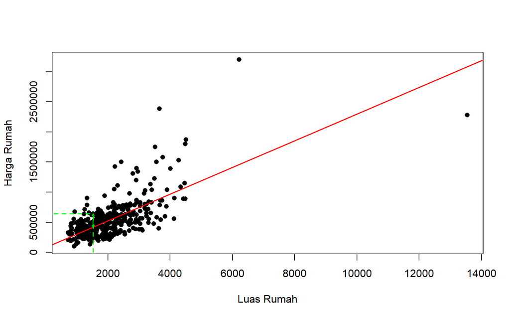

```r
titik <- 10
x_titik <- x[titik]
y_titik <- y[titik]
y_prediksi <- fitted(model_1)[titik]
# Colpal
color_palette <- colorRampPalette(colors = c("black"))

# Base
plot(x, y, pch = 16, xlab = "Luas Rumah", ylab = "Harga Rumah", col = color_palette(length(y)))
abline(model_1, col = "red", lwd = 1.5)

# xy strip
segments(x_titik, 0, x_titik, y_titik, col = "green", lty = 2, lwd = 1.5)
segments(0, y_titik, x_titik, y_titik, col = "green", lty = 2, lwd = 1.5)

# error line
segments(x_titik - 2, y_titik - 0.3, x_titik -2, y_prediksi + 0.3, col = "purple")

# error arrow
arrows(x_titik-2, y_titik-0.3, x_titik-2, y_prediksi+0.3, length = 0.04, col = "green")
arrows(x_titik-2, y_prediksi+0.3, x_titik-2, y_titik-0.3, length = 0.04, col = "green")
```

Berdasarkan *scatter plot* tersebut, dapat dilihat dari garis regresi yang terbentuk terdapat hubungan yang positif dan juga terlihat beberapa data pencilan yang menyimpang dari garis regresi tersebut.

# Keragaman Dugaan Parameter

```r
(anova.model <- anova(model_1))
```

```
## Analysis of Variance Table
##
## Response: y
##            Df     Sum Sq    Mean Sq F value    Pr(>F)
## x           1 1.9105e+13 1.9105e+13  314.27 < 2.2e-16 ***
## Residuals 366 2.2250e+13 6.0792e+10
## ---
## Signif. codes:  0 '***' 0.001 '**' 0.01 '*' 0.05 '.' 0.1 ' ' 1
```

```r
(KTG <- anova.model$`Mean Sq`[2])
```

```
## [1] 60791613969
```

```r
(galat.baku <- sqrt(KTG))
```

```
## [1] 246559.6
```

## 1.Dugaan Parameter $\beta_0$

Dengan nilai intersep(b0) sebesar 80895.31 ,selanjutnya akan dilakukan uji apakah ada variasi Harga Rumah (y) yang tidak dapat dijelaskan oleh besarnya Luas Rumah (x).

Hipotesis uji:

$H_0$:$β_0$ = 0 (Semua Harga Rumah dapat dijelaskan dengan besarnya Luas Rumah)

$H_1$:$β_0$ ≠ 0 (Ada Harga Rumah yang tidak dapat dijelaskan oleh besarnya Luas Rumah)

```r
(se_b0 <- sqrt(KTG*(1/368+mean(x)^2/sum((x-mean(x))^2))))
```

```
## [1] 29370.42
```

```r
(t_b0 <- beta0/se_b0)
```

```
## [1] 2.754312
```

$t_{hitung} = 2.754312$

Karena thitung > t(366, 0.025) maka *tolak H0*. Oleh karena itu, hal ini menunjukkan adanya Harga Rumah(y) yang tidak dapat dijelaskan oleh besarnya Luas Rumah(x) pada taraf nyata 5%.

## 2.Dugaan Parameter $\beta_1$

Dengan nilai slope(b1) sebesar 221.7485796 ,selanjutnya akan dilakukan uji apakah luas rumah (x) memiliki hubungan linear atau tidak terhadap harga rumah(y).

Hipotesis uji:

$H_0$:$β_1$ = 0 (Harga Rumah tidak memiliki hubungan linear dengan Luas Rumah)

$H_1$:$β_1$ ≠ 0 (Harga Rumah memiliki hubungan linear dengan Luas Rumah)

```r
(se_b1 <- sqrt(KTG/sum((x-mean(x))^2)))
```

```
## [1] 12.50869
```

```r
(t_b1 <- beta1/se_b1)
```

```
## [1] 17.72756
```

$t_{hitung} = 17.72756$

Karena thitung > t(366, 0.025) maka *tolak H0*. Oleh karena itu, hal ini menunjukkan adanya hubungan linier antara Luas Rumah(x) dan Harga Rumah(y). Hal tersebut juga memberikan bukti yang cukup untuk menyatakan bahwa Luas Rumah memengaruhi Harga rumah pada taraf nyata 5%.

# Nilai Koefisien Determinasi dan Korelasi

```r
(Koef_det<-1-(anova.model$`Sum Sq`[2]/sum(anova.model$`Sum Sq`)))
```

```
## [1] 0.4619753
```

```r
Korelasi <- sqrt(Koef_det)
Korelasi
```

```
## [1] 0.6796877
```

Nilai $R^2$ sebesar 0.461975343 menunjukkan bahwa sekitar 46.20% dari variasi harga rumah(y) dapat dijelaskan oleh persamaan regresi yang digunakan. Ini berarti terdapat sebagian besar variabilitas yang tidak dapat dijelaskan atau diprediksi oleh persamaan regresi. Sementara nilai korelasi sebesar 0.6796 menunjukan hubungan positif yang *cukup kuat* antara harga rumah(y) dan luas rumah(x).

# Selang Kepercayaan Parameter

Batas bawah untuk kedua dugaan parameter dalam taraf kepercayaan α=0.05 dapat dihitung sebagai berikut.

```r
#Batas Bawah beta0
(bb.b0 <- beta0 - abs(qt(0.025, df=368-2))*se_b0)
```

```
## [1] 23139.35
```

```r
#Batas Bawah beta1
(bb.b1 <- beta1 - abs(qt(0.025, df=368-2))*se_b1)
```

```
## [1] 197.1506
```

Sementara itu, batas atas untuk kedua dugaan parameter dalam taraf kepercayaan α=0.05 dapat dihitung sebagai berikut.

```r
#Batas Atas beta_0
(ba.b0 <- beta0 + abs(qt(0.025, df=368-2))*se_b0)
```

```
## [1] 138651.3
```

```r
#Batas Atas beta_1
(ba.b1 <- beta1 + abs(qt(0.025, df=368-2))*se_b1)
```

```
## [1] 246.3465
```

Sehingga dapat disusun suatu selang kepercayaan untuk $\beta_0$ sebagai berikut.

23139.35< $\beta_0$ <138651.3

Yang dapat dimaknai bahwa dalam taraf kepercayaan 95%, diyakini bahwa dugaan parameter $\beta_0$ berada dalam selang 23139.35 hingga 138651.3.

Sementara untuk selang kepercayaan $\beta_1$ adalah sebagai berikut

197.1506< $\beta_1$ <246.3465

Yang dapat dimaknai bahwa dalam taraf kepercayaan 95%, diyakini bahwa dugaan parameter $\beta_1$ berada dalam selang 197.1506 hingga 246.3465.

# Selang Kepercayaan Rataan (Nilai Harapan) Amatan

Misalkan kita ingin menduga nilai rataan (harapan) amatan ketika nilai x=3000. Kita dapat memanfaatkan fungsi predict untuk mendapatkan nilai dugaan dan selang kepercayaannya sebagai berikut.

```r
amatan.diduga <- data.frame(x=3000)
predict(model_1, amatan.diduga, interval = "confidence")
```

```
##        fit      lwr      upr
## 1 746141.1 712723.4 779558.7
```

Berdasarkan output sintaks di atas, diketahui bahwa rataan nilai $\hat{y}$ ketika nilai x=3000 adalah 746141.1. Selain itu, diindikasikan juga bahwa dalam taraf kepercayaan 95%, diyakini bahwa nilai rataan $\hat{y}$ ketika nilai x=3000 berada dalam selang 712723.4 hingga 779558.7 .

# Selang Kepercayaan Individu Amatan

Misalkan kita ingin menduga nilai individu amatan ketika nilai x=3000. Kita dapat memanfaatkan fungsi predict untuk mendapatkan nilai dugaan dan selang kepercayaannya sebagai berikut.

```r
predict(model_1, amatan.diduga, interval = "prediction")
```

```
##        fit      lwr     upr
## 1 746141.1 260139.6 1232142
```

Berdasarkan output sintaks di atas, diketahui bahwa nilai amatan individu $\hat{y}(x_i)$ ketika nilai x=3000 adalah 746141.1. Selain itu, diindikasikan juga bahwa dalam taraf kepercayaan 95%, diyakini bahwa nilai amatan individu $\hat{y}(x_i)$ ketika nilai x=3000 berada dalam selang 260139.6 hingga 1232142.

# Tabel Sidik Ragam

```r
dbr <- 1
dbg <- 368-2
dbt <- 368-1
JKR <- 1.91048E+13
JKG <- 2.22497E+13
JKT <- JKR+JKG
KTR <- JKR/dbr
```

```r
SK <- c("Regresi", "Galat", "Total")
db <- c(dbr, dbg, dbt)
JK <- c(JKR, JKG, JKT)
KT <- c(KTR, KTG, NA)
data_frame <- data.frame(SK, db, JK, KT)
data_frame
```

```
##        SK  db          JK           KT
## 1 Regresi   1 1.91048e+13 1.910480e+13
## 2   Galat 366 2.22497e+13 6.079161e+10
## 3   Total 367 4.13545e+13           NA
```

# Kesimpulan

Berdasarkan analisis yang kami lakukan, terdapat hubungan positif antara harga rumah dan luas rumah, yang mengindikasikan bahwa semakin besar luas suatu rumah, maka kemungkinan tinggi juga semakin naik harga rumah yang ditawarkan. Namun, faktor luas rumah tidak sepenuhnya menjadi faktor utama untuk menentukan harga rumah. Faktor-faktor lain seperti tahun pembuatan, banyaknya ruangan, dan banyak faktor lainnya.